# Prosper Loan Data Exploration by Yousr Mohamed Samy

> work with Prosper loans Dataset

This data set contains 113,937 loans with 81 variables on each loan, including loan amount, borrower rate (or interest rate), current loan status, borrower income, borrower employment status, borrower credit history, and the latest payment information.

Prosper is a company in the peer-to-peer lending industry,where the lenders are people who want to invest on funding , with the borrower’s history available for the investors ,along side creditscore and othe known evaluation metrics , Prosper use pre-set rates determined by Prosper’s loan pricing algorithm where it assigns a rating to the loan after it analyzes the borrower’s credit report and financial information , this metric is called Prosper Grading score

## Initial investigation of the dataset variables :

description of some of the variables :

1-**LoanStatus** : The current status of the loan: Cancelled, Chargedoff, Completed, Current, Defaulted, FinalPaymentInProgress, PastDue. The PastDue status will be accompanied by a delinquency bucket.

Defaulted : the term has come to be used to describe any debt that the card issuer no longer expects to be paid in full.

Chargedoff :When a credit card company has decided that the outstanding debt they’re owed is unlikely to be paid at all, they will typically “charge-off” the debt.

2-**Term** : The length of the loan expressed in months.

3-**ProsperRating (numeric)** : The Prosper Rating assigned at the time the listing was created: 0 - N/A, 1 - HR, 2 - E, 3 - D, 4 - C, 5 - B, 6 - A, 7 - AA. Applicable for loans originated after July 2009 –uni–

Prosper has provided a proprietary *“Prosper Rating”* for prospective borrowers for lenders to determine the risks based on the company’s estimation of that borrower’s *“estimated loss rate.”* According to the company, that figure is “determined by two scores: (1) the credit score, obtained from an official credit reporting agency, and the Prosper Score, figured in-house based on the Prosper population.”

Prosper Ratings, from lowest-risk to highest-risk, are labeled AA, A, B, C, D, E, and HR

Prosper rating Estimated Average Annual Loss Rate AA 0.00–1.99% A 2.00–3.99% B 4.00–5.99% C 6.00–8.99% Prosper rating Estimated Average Annual Loss Rate D 9.00–11.99% E 12.00–14.99% HR 15.00%+

4-**ProsperScore** : A custom risk score built using historical Prosper data. The score ranges from 1-10, with 10 being the best, or lowest risk score.

Applicable for loans originated after July 2009.

The Prosper score estimates the probability of a loan going “bad,” where “bad” is the probability of going 60+ days past due within the first twelve months from the date of loan origination

This is a score that they have developed internally based on the payment history of actual borrowers on their platform

5-**BorrowerAPR** :The Borrower’s Annual Percentage Rate (APR) for the loan.

APR stands for Annual Percentage Rate. The annual percentage rate on a loan is the amount the lender would charge if you borrowed the money for a year, as a percentage of the original loan. For instance at 40% APR, to borrow for a year you’d be charged 40% of the original loan

*note:On any borrowing, the two key things that affect the interest cost are the annual percentage rate of interest (APR) and how long you borrow for so If you pay back your loan in less than a year, you’ll pay less than the annual rate in interest.*

6-**EstimatedLoss** : Estimated loss is the estimated principal loss on charge-offs. Applicable for loans originated after July 2009.

The loss estimates are based on the historical performance of Prosper loans to borrowers with similar characteristics. They are not a guarantee and actual performance may differ from expected performance.

They use both the Prosper score and the borrowers credit information to determine the interest rate and the estimated loss rate.

Loss rates for a particular group of loans will be a function of the group’s delinquency and loss behavior over time, pre-payment behavior over time, and responsiveness to collections activity. For Prosper loans, the largest driver of the loss rate is the rate at which a group of loans becomes delinquent and charges off. A loan becomes “charged off” and is considered a loss when it becomes 121+ days past due.

7-**EstimatedEffectiveYield** :Effective yield is equal to the borrower interest rate (i) minus the servicing fee rate, (ii) minus estimated uncollected interest on charge-offs, (iii) plus estimated collected late fees. Applicable for loans originated after July 2009.

8-**ListingCategory**: The category of the listing that the borrower selected when posting their listing: 0 - Not Available, 1 - Debt Consolidation, 2 - Home Improvement, 3 - Business, 4 - Personal Loan, 5 - Student Use, 6 - Auto, 7- Other, 8 - Baby&Adoption, 9 - Boat, 10 - Cosmetic Procedure, 11 - Engagement Ring, 12 - Green Loans, 13 - Household Expenses, 14 - Large Purchases, 15 - Medical/Dental, 16 - Motorcycle, 17 - RV, 18 - Taxes, 19 - Vacation, 20 - Wedding Loans

9-**EmploymentStatus**: The employment status of the borrower at the time they posted the listing.

10-**EmploymentStatusDuration**: The length in months of the employment status at the time the listing was created.

11-**CreditScoreRangeLower** :The lower value representing the range of the borrower’s credit score as provided by a consumer credit rating agency.

note:A credit score is a numerical summary of a consumer’s creditworthiness that’s based on the information contained within their credit report. It reflects the likelihood that they will be able to pay back a credit obligation. it is provided by consumer credit rating agency

12-**CurrentDelinquencies** :Number of accounts delinquent at the time the credit profile was pulled.

13-**AmountDelinquent**: Dollars delinquent at the time the credit profile was pulled.

14-**IncomeRange**: The income range of the borrower at the time the listing was created.

15-**IncomeVerifiable** : The borrower indicated they have the required documentation to support their income.

16-**StatedMonthlyIncome**: The monthly income the borrower stated at the time the listing was created. 17-**OnTimeProsperPayments** Number of on time payments the borrower had made on Prosper loans at the time they created this listing. This value will be null if the borrower has no prior loans.

18-**ProsperPaymentsLessThanOneMonthLate** Number of payments the borrower made on Prosper loans that were less than one month late at the time they created this listing. This value will be null if the borrower had no prior loans.

19-**ProsperPaymentsOneMonthPlusLate** Number of payments the borrower made on Prosper loans that were greater than one month late at the time they created this

20-**DebtToIncomeRatio** The debt to income ratio of the borrower at the time the credit profile was pulled. This value is Null if the debt to income ratio is not available. This value is capped at 10.01 (any debt to income ratio larger than 1000% will be returned as 1001%).

21-**Occupation**: The Occupation selected by the Borrower at the time they created the listing.

22-**IsBorrowerHomeowner** A Borrower will be classified as a homowner if they have a mortgage on their credit profile or provide documentation confirming they are a homeowner.–uni–

23-**AvailableBankcardCredit** The total available credit via bank card at the time the credit profile was pulled.

# Univariate Plots Section

```
## [1] 113937     33
```

```
## 'data.frame':    113937 obs. of  33 variables:
##  $ ListingNumber            : int  193129 1209647 81716 658116 909464 1074836 750899 768193 1023355 1023355 ...
##  $ Term                     : int  36 36 36 36 36 60 36 36 36 36 ...
##  $ LoanStatus               : Factor w/ 12 levels "Cancelled","Chargedoff",..: 3 4 3 4 4 4 4 4 4 4 ...
##  $ ClosedDate               : Factor w/ 2803 levels "","2005-11-25 00:00:00",..: 1138 1 1263 1 1 1 1 1 1 1 ...
##  $ BorrowerAPR              : num  0.165 0.12 0.283 0.125 0.246 ...
##  $ LenderYield              : num  0.138 0.082 0.24 0.0874 0.1985 ...
##  $ EstimatedEffectiveYield  : num  NA 0.0796 NA 0.0849 0.1832 ...
##  $ EstimatedLoss            : num  NA 0.0249 NA 0.0249 0.0925 ...
##  $ ProsperRating..numeric.  : int  NA 6 NA 6 3 5 2 4 7 7 ...
##  $ ProsperScore             : num  NA 7 NA 9 4 10 2 4 9 11 ...
##  $ ListingCategory..numeric.: int  0 2 0 16 2 1 1 2 7 7 ...
##  $ BorrowerState            : Factor w/ 52 levels "","AK","AL","AR",..: 7 7 12 12 25 34 18 6 16 16 ...
##  $ Occupation               : Factor w/ 68 levels "","Accountant/CPA",..: 37 43 37 52 21 43 50 29 24 24 ...
##  $ EmploymentStatus         : Factor w/ 9 levels "","Employed",..: 9 2 4 2 2 2 2 2 2 2 ...
```

[output cut: 19 more lines]

```
##  ListingNumber          Term                       LoanStatus
##  Min.   :      4   Min.   :12.00   Current              :56576
##  1st Qu.: 400919   1st Qu.:36.00   Completed            :38074
##  Median : 600554   Median :36.00   Chargedoff           :11992
##  Mean   : 627886   Mean   :40.83   Defaulted            : 5018
##  3rd Qu.: 892634   3rd Qu.:36.00   Past Due (1-15 days) :  806
##  Max.   :1255725   Max.   :60.00   Past Due (31-60 days):  363
##                                    (Other)              : 1108
##                ClosedDate     BorrowerAPR       LenderYield
##                     :58848   Min.   :0.00653   Min.   :-0.0100
##  2014-03-04 00:00:00:  105   1st Qu.:0.15629   1st Qu.: 0.1242
##  2014-02-19 00:00:00:  100   Median :0.20976   Median : 0.1730
##  2014-02-11 00:00:00:   92   Mean   :0.21883   Mean   : 0.1827
##  2012-10-30 00:00:00:   81   3rd Qu.:0.28381   3rd Qu.: 0.2400
##  2013-02-26 00:00:00:   78   Max.   :0.51229   Max.   : 0.4925
##  (Other)            :54633   NA's   :25
##  EstimatedEffectiveYield EstimatedLoss   ProsperRating..numeric.
##  Min.   :-0.183          Min.   :0.005   Min.   :1.000
##  1st Qu.: 0.116          1st Qu.:0.042   1st Qu.:3.000
##  Median : 0.162          Median :0.072   Median :4.000
##  Mean   : 0.169          Mean   :0.080   Mean   :4.072
##  3rd Qu.: 0.224          3rd Qu.:0.112   3rd Qu.:5.000
##  Max.   : 0.320          Max.   :0.366   Max.   :7.000
##  NA's   :29084           NA's   :29084   NA's   :29084
##   ProsperScore   ListingCategory..numeric. BorrowerState
##  Min.   : 1.00   Min.   : 0.000            CA     :14717
##  1st Qu.: 4.00   1st Qu.: 1.000            TX     : 6842
##  Median : 6.00   Median : 1.000            NY     : 6729
##  Mean   : 5.95   Mean   : 2.774            FL     : 6720
##  3rd Qu.: 8.00   3rd Qu.: 3.000            IL     : 5921
##  Max.   :11.00   Max.   :20.000                   : 5515
##  NA's   :29084                             (Other):67493
##                     Occupation         EmploymentStatus
##  Other                   :28617   Employed     :67322
##  Professional            :13628   Full-time    :26355
##  Computer Programmer     : 4478   Self-employed: 6134
##  Executive               : 4311   Not available: 5347
##  Teacher                 : 3759   Other        : 3806
##  Administrative Assistant: 3688                : 2255
##  (Other)                 :55456   (Other)      : 2718
```

[output cut: 41 more lines]

```
##  Q4 2013:14450          63CA34120866140639431C9:     9
##  Q1 2014:12172          16083364744933457E57FB9:     8
##  Q3 2013: 9180          3A2F3380477699707C81385:     8
##  Q2 2013: 7099          4D9C3403302047712AD0CDD:     8
##  Q3 2012: 5632          739C338135235294782AE75:     8
##  Q2 2012: 5061          7E1733653050264822FAA3D:     8
##  (Other):60343          (Other)                :113888
##  MonthlyLoanPayment Recommendations      Investors
##  Min.   :   0.0     Min.   : 0.00000   Min.   :   1.00
##  1st Qu.: 131.6     1st Qu.: 0.00000   1st Qu.:   2.00
##  Median : 217.7     Median : 0.00000   Median :  44.00
##  Mean   : 272.5     Mean   : 0.04803   Mean   :  80.48
##  3rd Qu.: 371.6     3rd Qu.: 0.00000   3rd Qu.: 115.00
##  Max.   :2251.5     Max.   :39.00000   Max.   :1189.00
##
```

i can see that for (EstimatedEffectiveYield ,EstimatedLoss ,ProsperRating..numeric. , ProsperScore ) they have an equal number of missing values(29084) as they are dependent on each other , i will investigate more the listings of these values and whether i shall remove it

Member key :out of the 113937 listings there are 90831 unique borrower, investigating how listings are distributed among borowers

prosper score : it’s max value is 10 , where it is indicated in the summary a max of 11, ishall observe the listing corresponding to scores more than 10

ProsperPaymentsOneMonthPlusLate ,ProsperPaymentsLessThanOneMonthLate: it is median value is zero and also the first and third quatile values are zeros , also 91852 missing values are evident in these columns too

# Univariate Analysis

## investigating individual variables distributions of variables

### LoanStatus

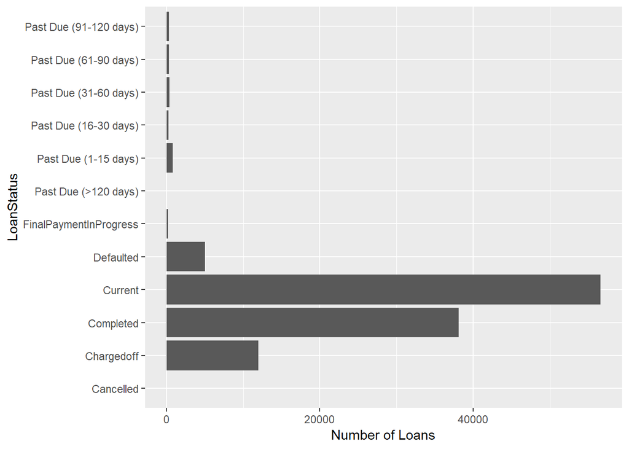

most of the status of loan in our dataset ranges between 4 categories : completed, chargedoff,defaulted,current and a smaller counts in other categories , i can re-categorize the levels into completed ,charged off ,defaulted ,other and shall see how each of the variables effect whether a loan is charged off or completed

### What is the percentage of chargedOFF,completed and defaulted loans in the Prosper dataset ?

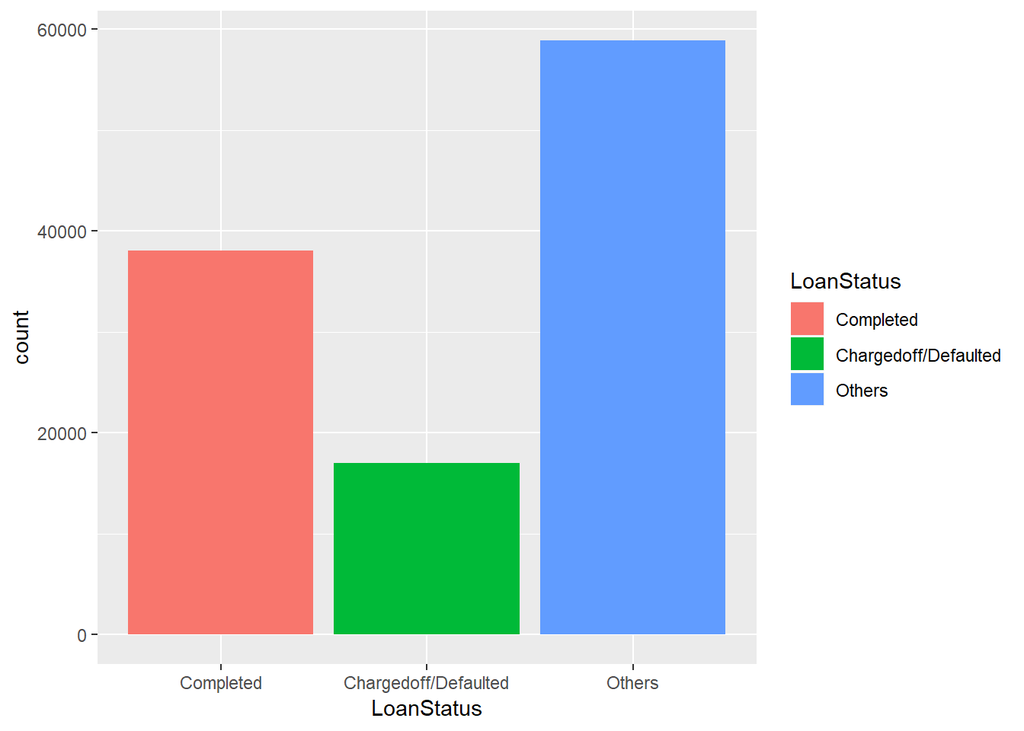

### EstimatedEffectiveYield variable :What is the mean expected yield when investing in Prosper Loans?

i shall include loans that are issued after 2009 in my univariate analysis:

```
##    Min. 1st Qu.  Median    Mean 3rd Qu.    Max.    NA's
##  -0.183   0.116   0.162   0.169   0.224   0.320   29084
```

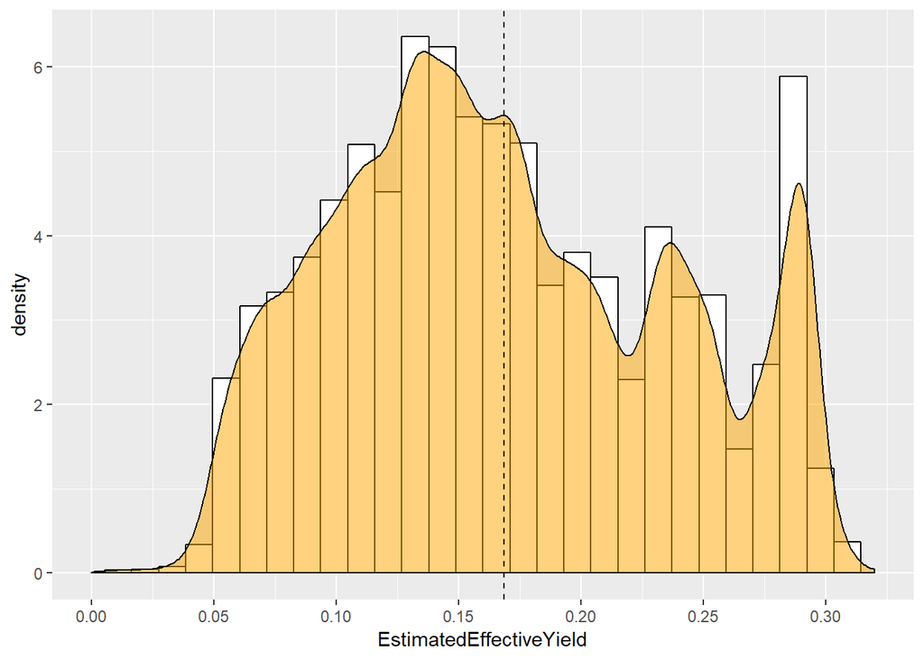

In the EstimatedEffectiveYield plot, I have found outliers that lies below 0 value,again returning to the how the estimated yield is calculated , it is the is equal to the borrower interest rate (i) minus the servicing fee rate, (ii) minus estimated uncollected interest on charge-offs, (iii) plus estimated collected late fees. this can mean that the fees and the uncollected interests for some lenders exceeded the interest rate.

i excluded this group from the plot to decrease outliers so i added limits to the plot to include the +ve values only as they counted 190 out of 84853 observations, the expected estimated effective yield is approximately 0.1687 , where it peaks again at 0.28 , what attributes to having high estimated effective yield ? i will investigate that in the bi, and multi variant analysis

### ProsperRating (numeric) : What is the distribution of ratings among the listed loans ? are more rated of higher risk ?

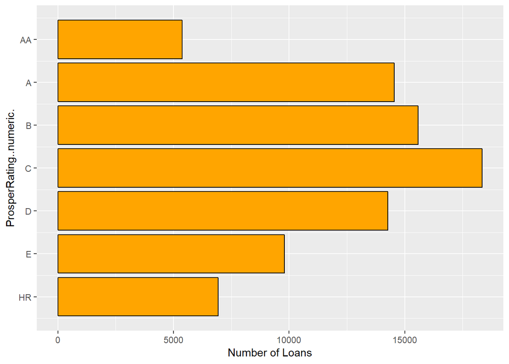

the variable has the same case of estimated effective yield where it’s values are only evident after july 2009 , Prosper Ratings, from lowest-risk to highest-risk, are labeled AA, A, B, C, D, E, and HR the rating is given to a loan according to it’s estimated loss rate relative to the borrower’s profile numeric rating : 0 - N/A, 1 - HR, 2 - E, 3 - D, 4 - C, 5 - B, 6 - A, 7 - AA

most of the loans in the dataset correspond to C which is medium risk , where the lowest count is for the least risk loan , Is the prosper grade effective ? does really lower risk have a lower percentage of chargedoff loans ? How prospergrade relate to the interest rate of the loan and the effective yield of the lender ?

### EstimatedLoss :Now what is the mean expected loss if someone invest in prosper loans ?

```
##    Min. 1st Qu.  Median    Mean 3rd Qu.    Max.    NA's
##   0.005   0.042   0.072   0.080   0.112   0.366   29084
```

```
##    Min. 1st Qu.  Median    Mean 3rd Qu.    Max.
## 0.00490 0.03740 0.05990 0.06232 0.08900 0.11900
```

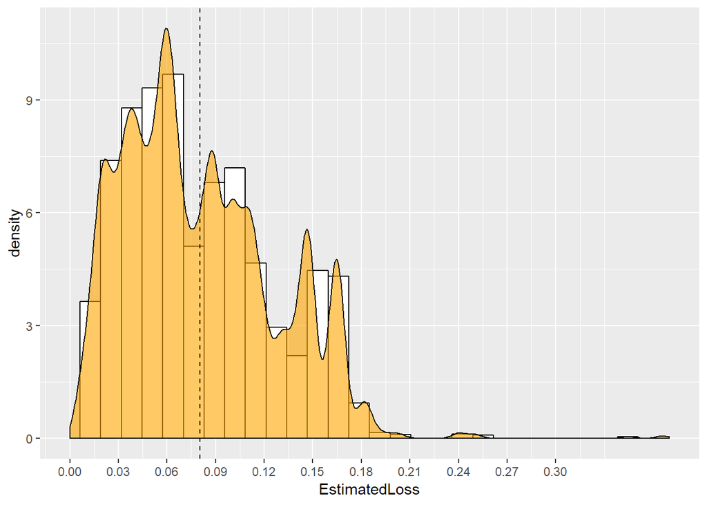

the variable has the same case of estimated effective yield where it’s values are only evident after july 2009 , for the plot i used breaks every 0.01 period ,From the summary of that variables there exist outliers that can effect the mean , the mean expected loss with outliers reaches 8% , while when removing outliers is 6%

the maximum estimated loss is 36% and it is a small portion of the all loans , we can say that common estimated losses are between 3%-9% , where for each estimated loss the Prosper scoring differ according to this table provided in Prosper’s official website :

rating Estimated Average Annual Loss Rate AA 0.00–1.99% A 2.00–3.99% B 4.00–5.99% C 6.00–8.99% Prosper rating Estimated Average Annual Loss Rate D 9.00–11.99% E 12.00–14.99% HR 15.00%+

and that follows the fact that most loans are rated to be B,C,D

### LoanOriginalAmount : What are the typical amounts of money lent through Prosper ?

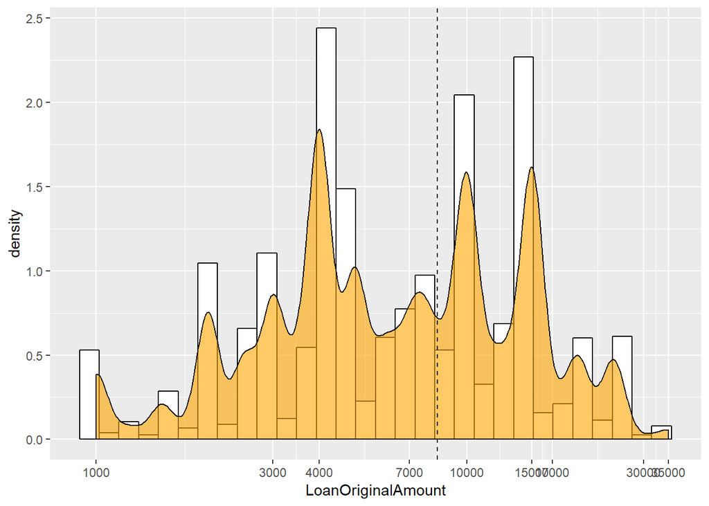

### IncomeRange: What is the income range of most Borrowers ?

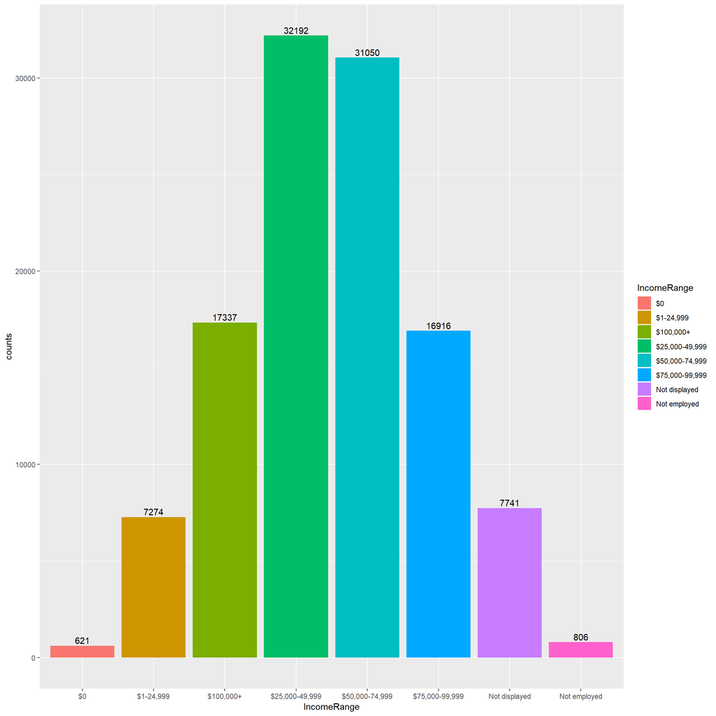

most of our dataset had borrowers from 25000-75000 income , there is a minimum criteria to borrow at prosper that Stated that income should be greater than $0 but there are 621 listing with income =0 i shall investigate that further

understanding the data for income zero category ,there are 621 listings in this category, their employment status shows that most of them are employed whether self or full time employed , with only 11 as unemployed

i guess it has something to do with their current income , as these 621 have different prosper gradings and not all of them marked as high risk as expected

data for the unemployed :

for people who registered as unemployed, there are 806 listings in this category , there are 771 that listed their occupation as other , their mean rating is 2 with max 7 ,but taking into account that most of these people stated a duration where they worked before , later we can investigate how this group APR and rating differ from the median APR , also the percentage that was charged off

### BorrowerAPR : What is the mean Prosper’s interest rate among the loans given ?

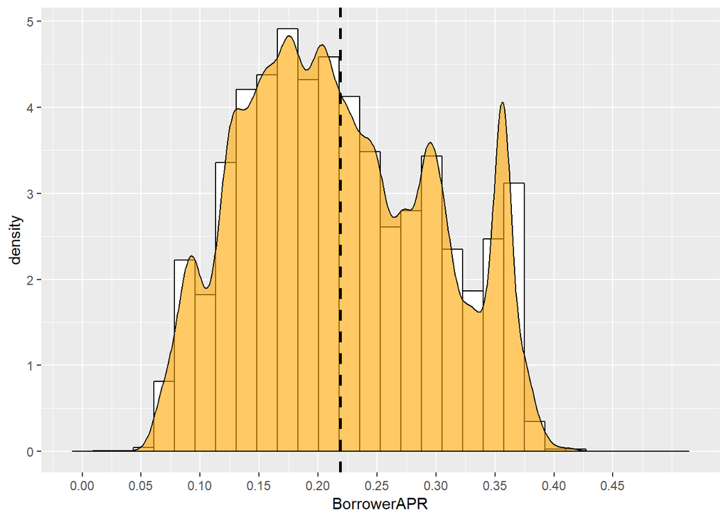

the NA values attribute to the fact that these loans were given before 2009 , where the rate of interest was set by a bid between lenders and borrowers

the distribution shows that the average interest rate mainly ranges from 12% to 25% where it can reaches 40% at some instances

i have gathered a 10334 data sets with interest rate more than 35% to compare with median APR interest rate,usually loans with higher risk have a higher interest rate

### DebtToIncomeRatio :Out of all Borrowers , Is the amount of loan proportional to their Income ?

```
##    Min. 1st Qu.  Median    Mean 3rd Qu.    Max.    NA's
##   0.000   0.140   0.220   0.276   0.320  10.010    8554
```

```
##    Min. 1st Qu.  Median    Mean 3rd Qu.    Max.
##   3.070   5.980  10.010   8.367  10.010  10.010
```

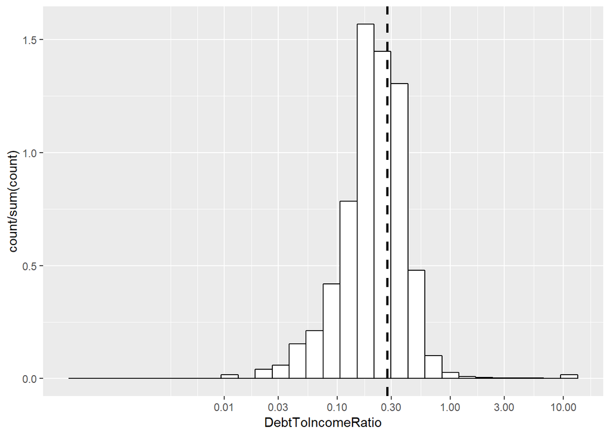

The variable here is the debt to income ratio From the summary There is outliers in this variable as the third quartile data ends at 32% while maximum values reaches 1001% i transformed the debttoincome variable to logscale for better represention , also i plotted the y-axis as a proportion of the total count

the average debt to income ratio ranges from 10% to 100% , with a mean of approxmatly 30% where values with higher ratio represent 5% of our dataset which answers our question , most of the loans are somehow proportional to the amount of debt

### Term : What is the term of most loans ?1 year,3 years or 5 years?

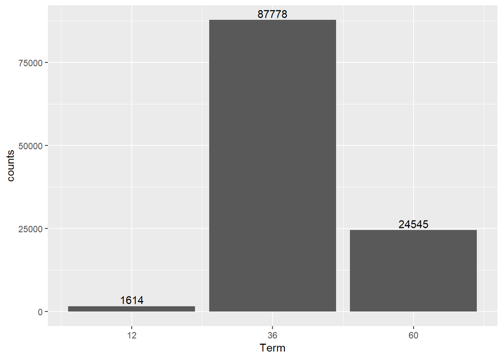

most of the loans in our dataset have a 3 year span for it’s fullfilment

### IncomeVerifiable :Are te incomes stated in Borrower’s profiles true ?

```
##      False       True
## 0.07608591 0.92391409
```

revealing whether the income listed is supported by documents , 92% of the stated incomes are verivfied by documents

### ListingCategory:Why People usually take Loans ?

```
##
## Debt Consolidation    HomeImprovement           Business
##              58308               7433               7189
##      Personal Loan        Student Use               Auto
##               2395                756               2572
##              Other      Baby&Adoption    Engagement Ring
##              27746                199                217
## Household Expenses    Large Purchases     Medical/Dental
##               1996                  0               1522
##         Motorcycle              Taxes           Vacation
##                304                885                768
##      Wedding Loans
##                771
```

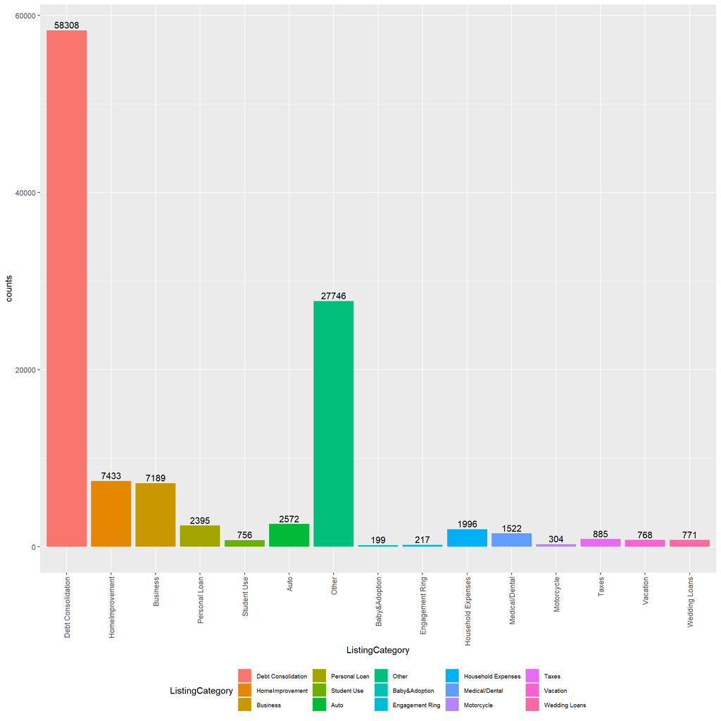

### Occupation of the borrower:Is there is a common occupation among Loan Borrwers in Prosper ?

```
##
##  FALSE   TRUE
## 110349   3588
```

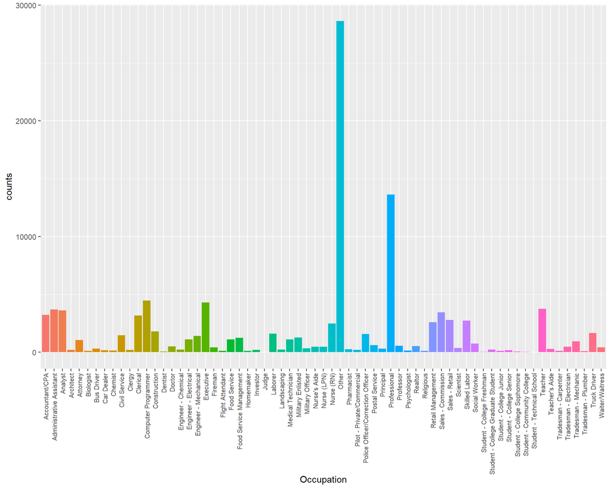

### EmploymentStatusDuration : Are the Borrowers People with alot of years of experience ?

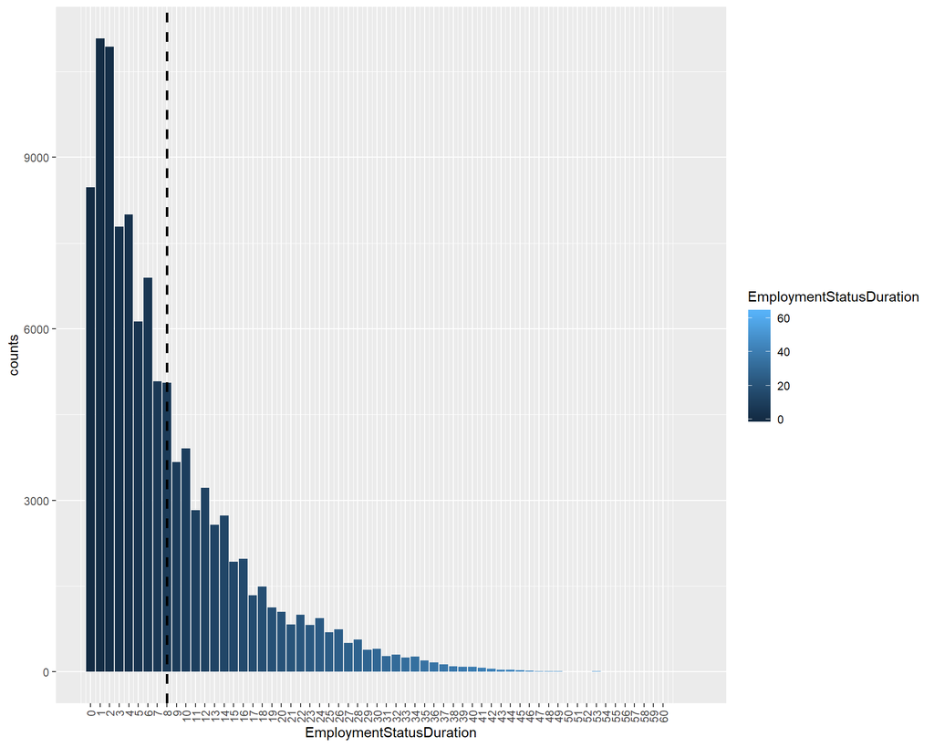

the average employment years tends to be around 8 years , most of the borrowers are at the start of their careers with 1 or 2 years of experience , their some rare cases with 60 or 50 years of experience

from my readings referenced in the attached txt.file usually for home loans at least two years of employment duration for most banks is a must

### What is the structure of your dataset?

This data set contains 113,937 loans with 81 variables on each loan, including loan amount, borrower rate (or interest rate), current loan status, borrower income, borrower employment status, borrower credit history, and the latest payment information.

there number of nulls in each column variable , some of them due to change of the policy of Prosper company by 2009 and using different metrics for grading

### What is/are the main feature(s) of interest in your dataset?

i have main features that i think guide and interpret the lending process in Prosper :

#### Prosper grading :

the grade that is given to the loan is determined by loss estimated and determines the total interest rate , risker loans have higher rates , how these gradings change with the finicial state of the borrower , and do they help? are charged off loans are sufficiently lower in less risker loans?

#### status of the loan :

chargedoff or defaulted or completed or deliquent from 1 day to above 120 days comparing the proportion of charged off and defaulted loans to completed loans of each group or category of the borrower’s features

#### BorrowerAPR :

the annual loan rate , how high are the rates , and what are the prominent characteristics of a high interest rate and low interest one ?i want through the data get the best condition for the borrower for a loan with lowest rate

#### EstimatedEffectiveYield :

Effective yield is equal to the borrower interest rate (i) minus the servicing fee rate, (ii) minus estimated uncollected interest on charge-offs, (iii) plus estimated collected late fees. this variable quantifiy the lender gain across different variants of the loan

#### term :

the term of the loan , are longer term loans with less monthly payment rates give the lender a better yield or those with shorter terms and higher monthly payment

what are the finicial state of people borrowing money ? how different people with different incomes takes different risks?

how much of the investors takes risks and how much of them achieve profit out of it ? ### What other features in the dataset do you think will help support yourinvestigation into your feature(s) of interest?

i needed variables to quantifiy the finicial state of a borrower , there were alot of variables but i choose :

available bank card credit

mean LoanOriginalAmount

mean monthlyincome

loan status

DebtToIncomeRatio

IsBorrowerHomeowner

EmploymentStatus

EmploymentStatusDuration

prosper grading

CreditScoreRangeUpper

CurrentDelinquencies

### Did you create any new variables from existing variables in the dataset?

for several variables i changed the levels of factors of varaibles , usually grouping similar categories into one category

### Of the features you investigated, were there any unusual distributions? Did you perform any operations on the data to tidy, adjust, or change the form of the data? If so, why did you do this?

I transformed several variables distribution using the log transformation, there were missing data and unrealistic values that i found like finding negative values in seemingly positive ones , for every alteration i did , i wrote te details under it’s plot with summaries provided

# Bivariate Plots Section

First i will view the Bivariate -pairs model i hashed the line of exceution of ggpairs as it made knitting the html kept freezing

### Does the income of the Borrower effect how Prosper company grade him ?

here we are using the income range

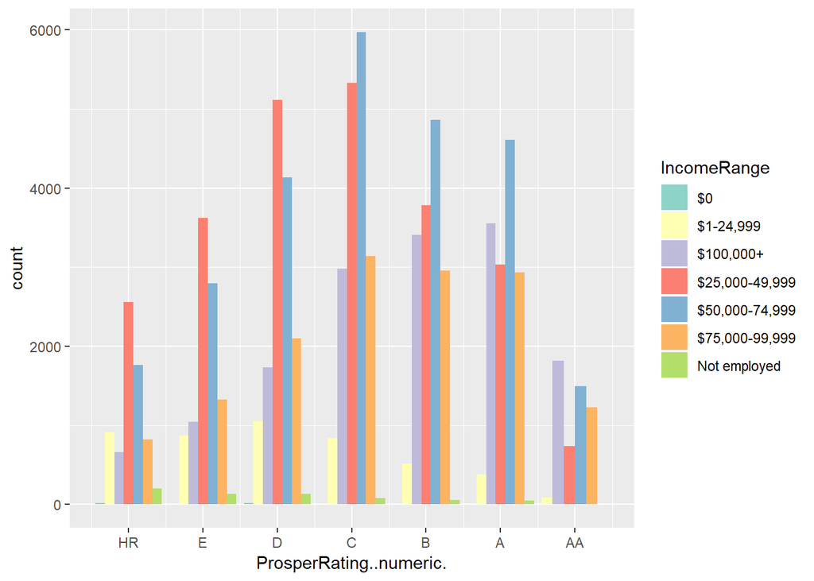

using the stated monthly income

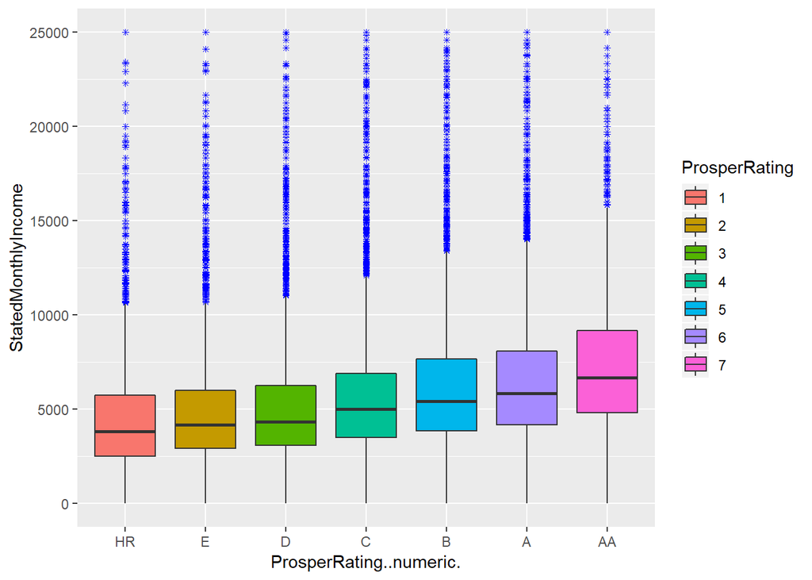

```
##
##  Pearson's product-moment correlation
##
## data:  as.numeric(ProsperRating..numeric.) and StatedMonthlyIncome
## t = 27.594, df = 84851, p-value < 2.2e-16
## alternative hypothesis: true correlation is not equal to 0
## 95 percent confidence interval:
##  0.08763298 0.10097022
## sample estimates:
##        cor
## 0.09430583
```

using the boxplot we can see that the median of AA grade is higher being compared to the HR grade , while the difference is seemingly subtle when comparing the grades in between

the correlation coefficient shows very weak correlation between prospergrading and income

### Is Prosper grading an efficient guide for safer loans ?

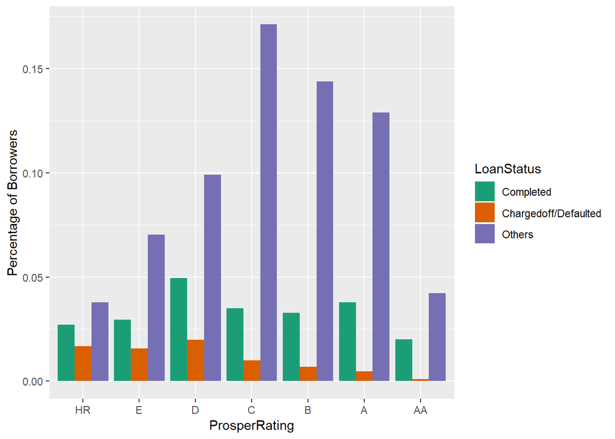

we can see that for safe graded loans that percentage of charged off loans is the lowest and increase as we increase the grade , to make sure of the differences i shall find the exact percentage

```
##
##      FALSE       TRUE
## 0.98454952 0.01545048
```

```
##
##     FALSE      TRUE
## 0.7946647 0.2053353
```

```
##
##     FALSE      TRUE
## 0.8825137 0.1174863
```

we can see that 1.5% of the total loans of AA grade are defaulted or chargedoff , 20% of HR grade loans are defaulted or charged off, where 11% of total D grade loans are defaulted or chargedoff

### If you don’t own a home , will the inerest rate increase ? if yes by how much ?

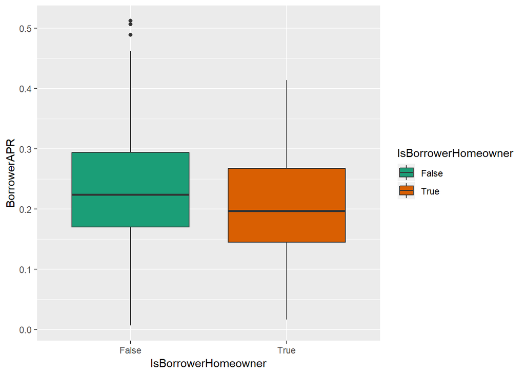

```
##    Min. 1st Qu.  Median    Mean 3rd Qu.    Max.    NA's
## 0.00653 0.16988 0.22362 0.22960 0.29371 0.51229      25
```

```
##    Min. 1st Qu.  Median    Mean 3rd Qu.    Max.
## 0.01647 0.14494 0.19645 0.20825 0.26762 0.41355
```

### will the prosper grading differ for home owners ?

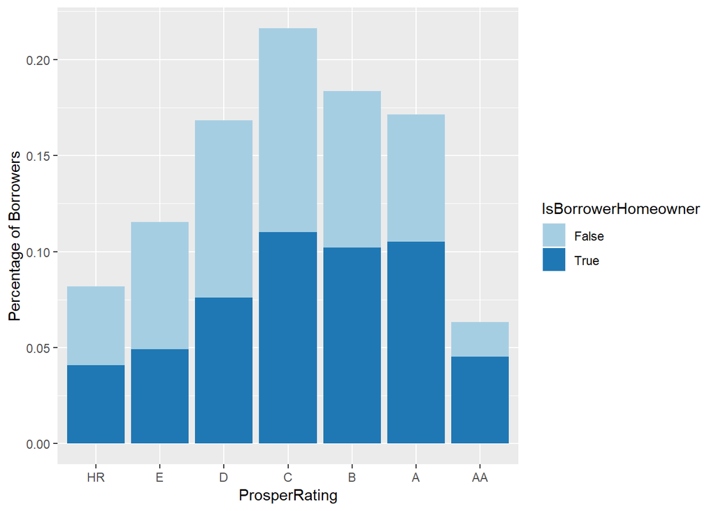

### How the interest rate differ according to your employment Status ?

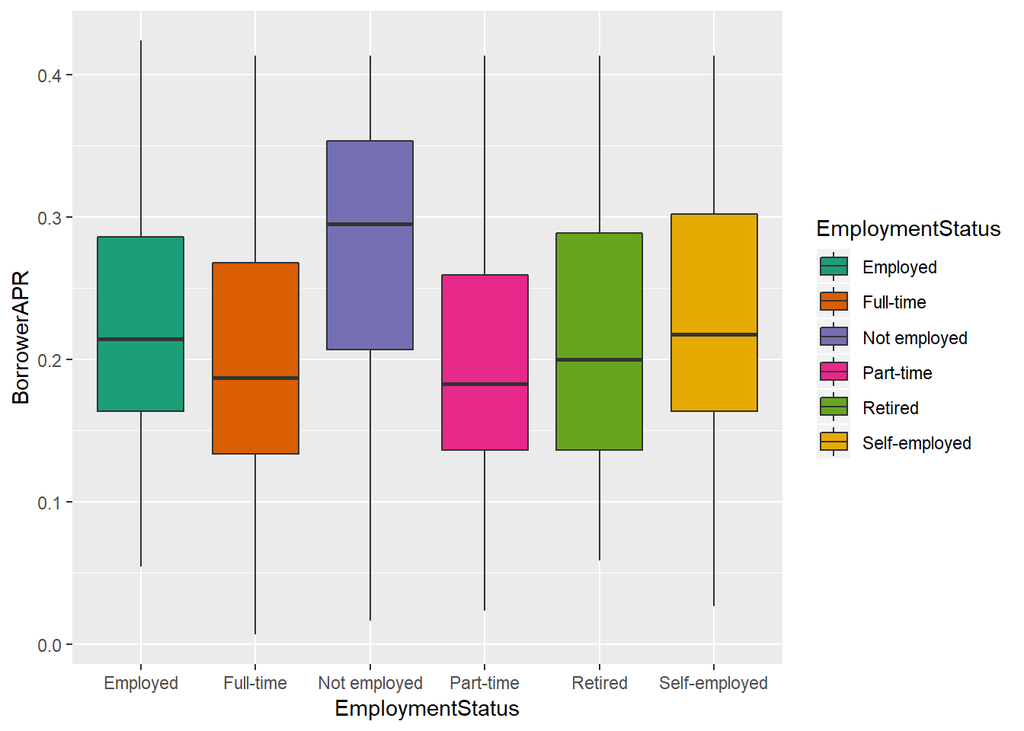

```
##    Min. 1st Qu.  Median    Mean 3rd Qu.    Max.
## 0.01657 0.20705 0.29510 0.27576 0.35356 0.41355
```

```
##    Min. 1st Qu.  Median    Mean 3rd Qu.    Max.
## 0.05436 0.16361 0.21434 0.22356 0.28595 0.42395
```

```
##    Min. 1st Qu.  Median    Mean 3rd Qu.    Max.
## 0.02659 0.16324 0.21761 0.23029 0.30201 0.41355
```

I excluded the ‘other’ and vacant categories from employment status for the unemployed the median of theinterest rate increase up to 29% ,interestingly enough among tthe highest Borrower’s rate categories was people who were listed as employed scoring higher rates than the retired and slightly lower than the the self employed with median interest rate of 21.4%

we note from the matrix plot that employment duration doesn’t have a great impact in the interest rate with 0.008 pearson correlation score, current deliquenices of a borrower interestingly doesn’t have a great impact as i imagined with a 0.321 correlation score

### what is a better strategy for investing in loans ?Lending larger amounts of money or investing in several smaller loans?

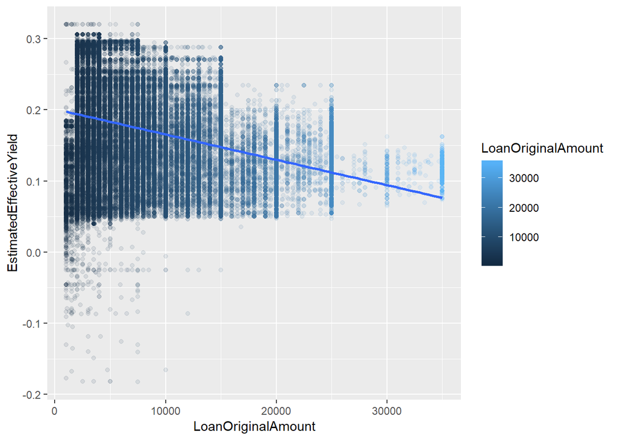

```
##    Min. 1st Qu.  Median    Mean 3rd Qu.    Max.
##    1000    4000    4000    5906    7500   25000
```

it appears that Several smaller Loans are more beneficial ! it shows that most of the yield that exceeds the 30% are below 15000 , where for the loans that have a median of 4000 and third quartile limit of 7500 dollars

### Is investing in longer term loans results in more yield ?

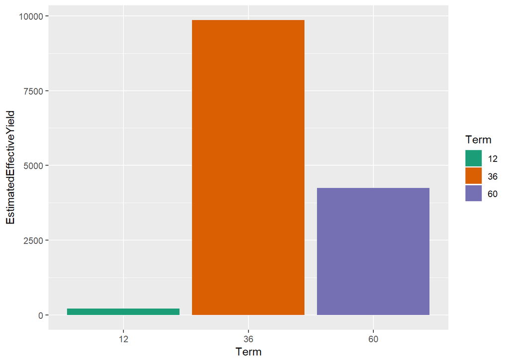

we can see that longer terms loans gives more effective yield but the 3 years loan term seem to have the maximum yoeld , theses results can have something to do with the distribution of different loan terms in the dataset as the 3 years loan prevails

## Is the percentage of chargedoff or defaulted loans the same for all loans ?

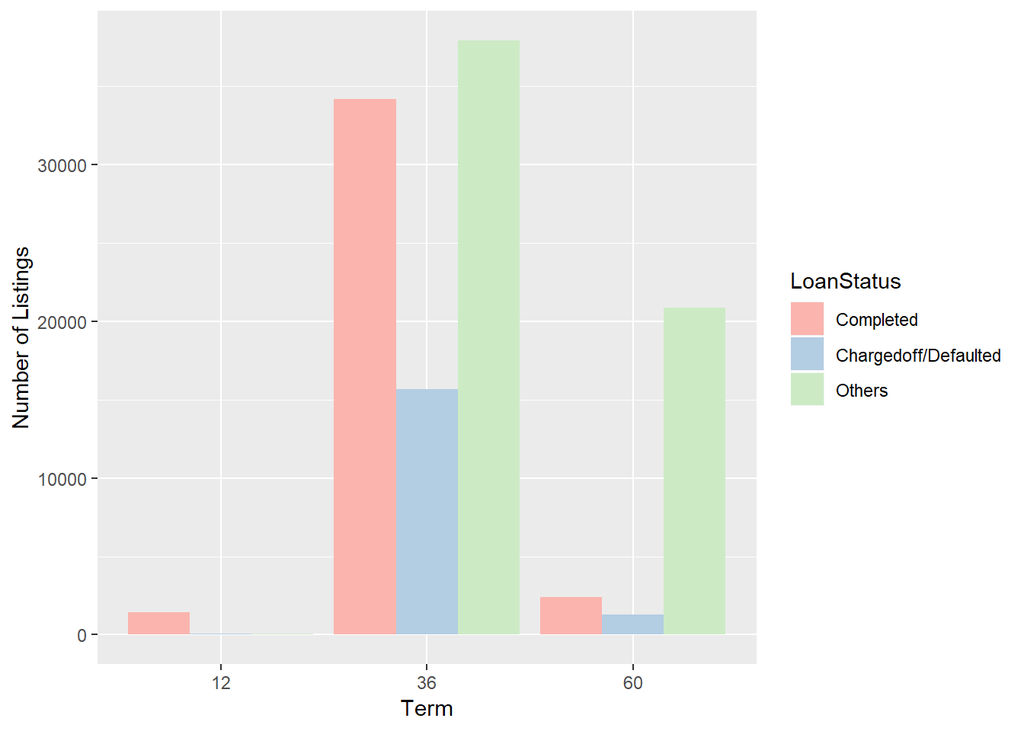

for more accurate findings , explore the summaries

```
##
##      FALSE       TRUE
## 0.94919455 0.05080545
```

```
##
##    FALSE     TRUE
## 0.821641 0.178359
```

```
##
##      FALSE       TRUE
## 0.94817682 0.05182318
```

5% of the 1 year loans has defaulted or charged off , 17% of the 3 years loan period has defaulted or charged off , 5.1% of 5 years loans has defaulted or charged off

# Bivariate Analysis

### What was the strongest relationship you found?

the prosper grading relating to the percentage of charged off or defaulted loans

# Multivariate Plots Section

### are longer term loans with less monthly payment rates give the lender a better yield or those with shorter terms and higher monthly payment

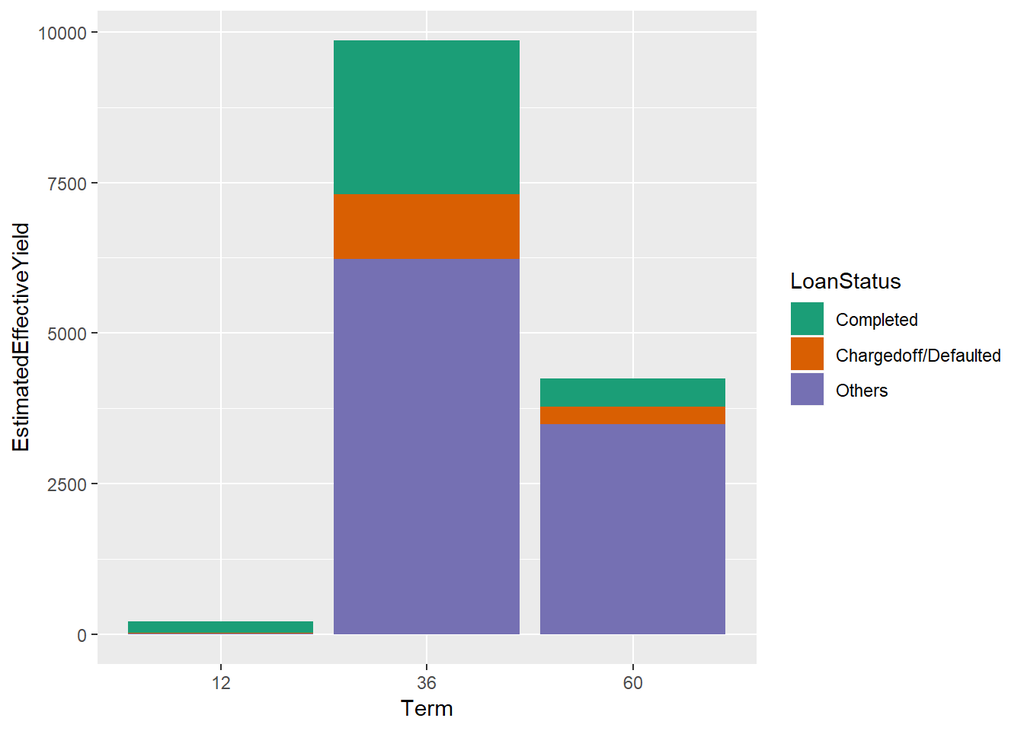

### does lending more of higher risk gives more yield , or is it more wise to invest in smaller loans with different prosper rating?

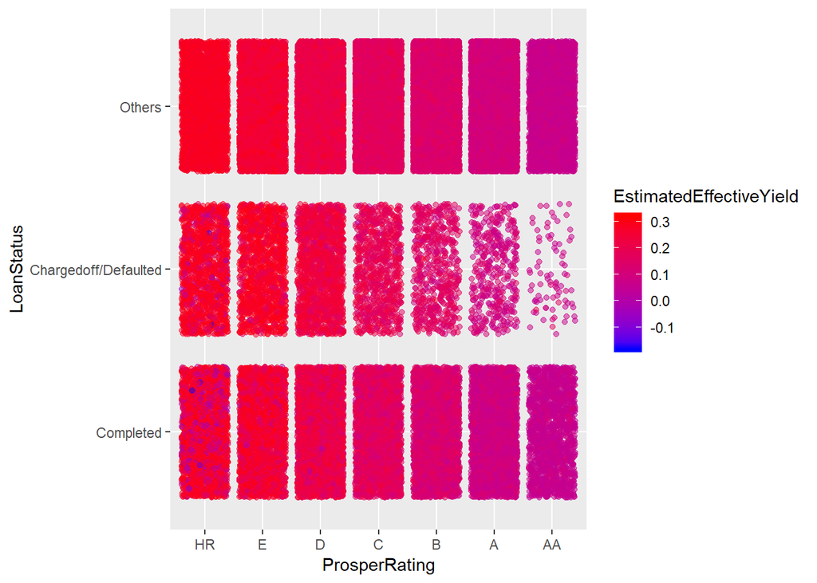

we see that indeed choosing a higher risk loan can give more yield but with a higher chance of the loan being charged off or defaulted

### for those who had negative yield is there is common characteristic ?

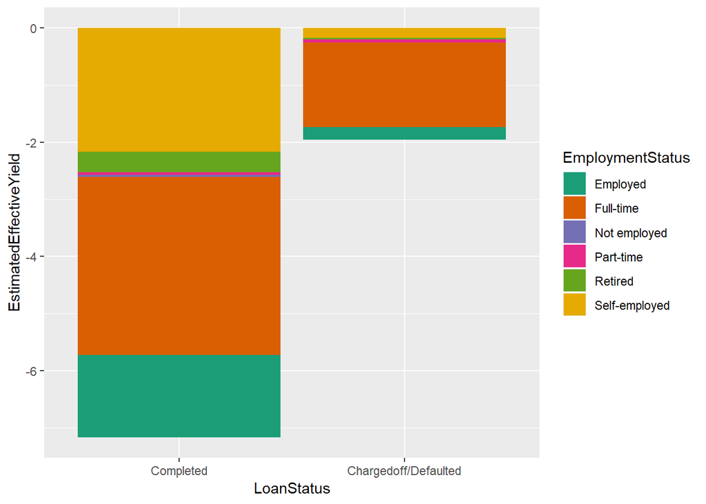

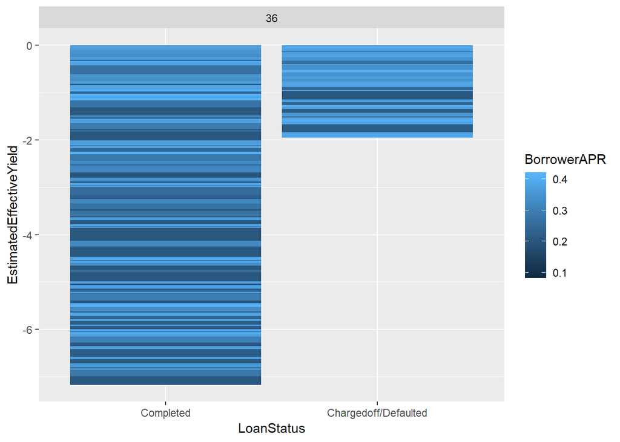

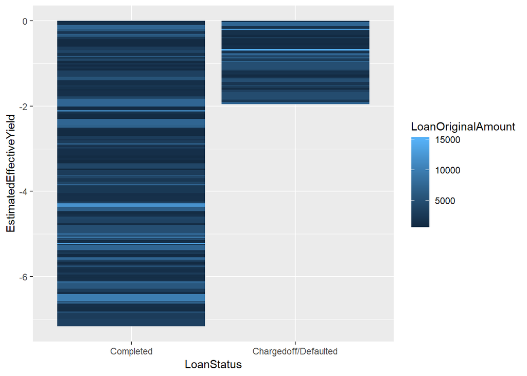

we note that the estimated yield is equal to the borrower interest rate (i) minus the servicing fee rate, (ii) minus estimated uncollected interest on charge-offs, (iii) plus estimated collected late fees.

but we can see that the the most negative estimated yield are completed and are not charged off and that is a surprising effect , also observing the interest rate , they are not expectionally low to yield this value

### For those who registered their job on the listing as ‘not employed’ did they get higher interest and did they defaulted or completed their loans ?

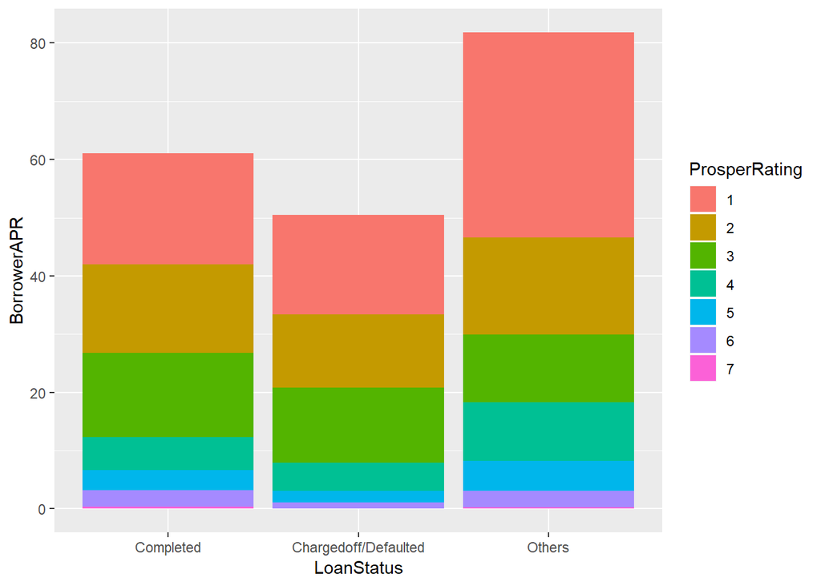

### Fitting a Logistic regression model to predict whether a loan will be charged off/defaulted or completed

```
##
##            Completed Chargedoff/Defaulted               Others
##                38074                17010                58853
```

```
## [1] 26005    16
```

```
##
##            Completed Chargedoff/Defaulted
##                19664                 6341
```

```
##
##     0     1
##  6341 19664
```

```
##
##     1     2     3     4     5     6     7     8
## 16479  6530     0   375   798   224   269  1330
```

```
##
##             $0      $1-24,999      $100,000+ $25,000-49,999 $50,000-74,999
##             30           1951           3932           8327           7366
## $75,000-99,999  Not displayed   Not employed
##           4024              0            375
```

```
##
##    1    2    3    4    5    6    7    8    9
##   30 1951 3932 8327 7366    0 4024  375    0
```

```
##
## False  True
## 12748 13257
```

```
##
##     0     1
## 12748 13257
```

```
## 'data.frame':    26005 obs. of  16 variables:
##  $ Term                    : Factor w/ 3 levels "12","36","60": 2 2 3 2 2 2 2 1 2 2 ...
##  $ BorrowerAPR             : num  0.358 0.28 0.307 0.113 0.128 ...
##  $ EstimatedEffectiveYield : num  0.2896 0.2126 0.2473 0.0608 0.0897 ...
##  $ ProsperRating..numeric. : Factor w/ 7 levels "1","2","3","4",..: 1 3 2 6 6 7 3 2 3 2 ...
##  $ EmploymentStatus        : Factor w/ 7 levels "1","2","4","5",..: 4 1 1 2 1 1 1 1 1 1 ...
##  $ EmploymentStatusDuration: num  10 0 2 1 4 1 13 6 3 18 ...
##  $ IsBorrowerHomeowner     : Factor w/ 2 levels "0","1": 2 1 1 2 1 1 2 1 1 2 ...
##  $ CreditScoreRangeUpper   : int  719 699 679 719 759 779 739 619 679 699 ...
##  $ CurrentDelinquencies    : int  0 0 0 0 1 0 0 0 1 6 ...
##  $ AmountDelinquent        : num  0 0 0 0 42488 ...
##  $ AvailableBankcardCredit : num  178 607 3619 30794 25779 ...
##  $ IncomeRange             : Factor w/ 7 levels "1","2","3","4",..: 5 4 4 6 4 3 3 5 3 5 ...
##  $ StatedMonthlyIncome     : num  5500 2500 3886 6667 3750 ...
##  $ LoanOriginalAmount      : int  4000 2000 4000 4000 10000 16000 2000 3000 4500 2500 ...
##  $ MonthlyLoanPayment      : num  173.7 78.7 124.8 0 322.6 ...
##  $ LoanStatus              : Factor w/ 2 levels "0","1": 1 1 2 2 2 2 1 2 2 1 ...
```

```
##
## Call:
## glm(formula = LoanStatus ~ ., family = binomial, data = training_set)
##
## Deviance Residuals:
##     Min       1Q   Median       3Q      Max
## -2.8820   0.1449   0.5211   0.7896   1.7904
##
## Coefficients: (1 not defined because of singularities)
##                            Estimate Std. Error z value Pr(>|z|)
## (Intercept)               3.803e+00  6.142e-01   6.192 5.95e-10 ***
## Term36                   -1.664e+00  1.577e-01 -10.547  < 2e-16 ***
## Term60                   -2.143e+00  1.846e-01 -11.611  < 2e-16 ***
## BorrowerAPR              -6.871e+00  8.019e-01  -8.568  < 2e-16 ***
## EstimatedEffectiveYield  -4.963e+00  3.816e-01 -13.007  < 2e-16 ***
## ProsperRating..numeric.2  1.675e-01  5.505e-02   3.043  0.00234 **
## ProsperRating..numeric.3 -1.211e-01  7.394e-02  -1.638  0.10148
## ProsperRating..numeric.4 -3.255e-01  1.136e-01  -2.866  0.00415 **
## ProsperRating..numeric.5 -6.410e-01  1.513e-01  -4.237 2.26e-05 ***
## ProsperRating..numeric.6 -9.193e-01  1.930e-01  -4.762 1.92e-06 ***
## ProsperRating..numeric.7 -6.831e-01  2.522e-01  -2.708  0.00676 **
## EmploymentStatus2        -2.869e-02  4.958e-02  -0.579  0.56282
## EmploymentStatus4        -2.484e-01  4.508e-01  -0.551  0.58155
## EmploymentStatus5        -4.796e-01  8.426e-02  -5.692 1.26e-08 ***
## EmploymentStatus6         2.035e-01  1.984e-01   1.026  0.30492
## EmploymentStatus7        -3.185e-01  1.577e-01  -2.019  0.04346 *
## EmploymentStatus8        -3.543e-01  7.081e-02  -5.003 5.64e-07 ***
## EmploymentStatusDuration -1.966e-03  2.253e-03  -0.873  0.38280
## IsBorrowerHomeowner1     -3.596e-02  3.620e-02  -0.993  0.32048
## CreditScoreRangeUpper     2.692e-03  4.520e-04   5.957 2.58e-09 ***
## CurrentDelinquencies     -1.039e-01  1.365e-02  -7.611 2.72e-14 ***
## AmountDelinquent          6.002e-06  2.570e-06   2.336  0.01951 *
## AvailableBankcardCredit  -1.980e-06  1.079e-06  -1.835  0.06650 .
## IncomeRange2              5.666e-02  4.380e-01   0.129  0.89706
## IncomeRange3              7.510e-01  4.505e-01   1.667  0.09553 .
## IncomeRange4              1.995e-01  4.363e-01   0.457  0.64753
## IncomeRange5              4.794e-01  4.381e-01   1.094  0.27384
## IncomeRange7              7.198e-01  4.419e-01   1.629  0.10337
## IncomeRange8                     NA         NA      NA       NA
## StatedMonthlyIncome       2.176e-05  9.441e-06   2.305  0.02119 *
## LoanOriginalAmount        1.573e-05  1.345e-05   1.169  0.24231
## MonthlyLoanPayment       -1.475e-03  3.668e-04  -4.023 5.75e-05 ***
## ---
## Signif. codes:  0 '***' 0.001 '**' 0.01 '*' 0.05 '.' 0.1 ' ' 1
##
## (Dispersion parameter for binomial family taken to be 1)
##
##     Null deviance: 25992  on 23395  degrees of freedom
## Residual deviance: 22983  on 23365  degrees of freedom
##   (9 observations deleted due to missingness)
## AIC: 23045
##
## Number of Fisher Scoring iterations: 5
```

```
## 'data.frame':    26005 obs. of  12 variables:
##  $ Term                   : Factor w/ 3 levels "12","36","60": 2 2 3 2 2 2 2 1 2 2 ...
##  $ BorrowerAPR            : num  0.358 0.28 0.307 0.113 0.128 ...
##  $ EstimatedEffectiveYield: num  0.2896 0.2126 0.2473 0.0608 0.0897 ...
##  $ EmploymentStatus       : Factor w/ 7 levels "1","2","4","5",..: 4 1 1 2 1 1 1 1 1 1 ...
##  $ CreditScoreRangeUpper  : int  719 699 679 719 759 779 739 619 679 699 ...
##  $ CurrentDelinquencies   : int  0 0 0 0 1 0 0 0 1 6 ...
##  $ AmountDelinquent       : num  0 0 0 0 42488 ...
##  $ StatedMonthlyIncome    : num  5500 2500 3886 6667 3750 ...
##  $ LoanOriginalAmount     : int  4000 2000 4000 4000 10000 16000 2000 3000 4500 2500 ...
##  $ ProsperRating..numeric.: Factor w/ 7 levels "1","2","3","4",..: 1 3 2 6 6 7 3 2 3 2 ...
##  $ AvailableBankcardCredit: num  178 607 3619 30794 25779 ...
##  $ LoanStatus             : Factor w/ 2 levels "0","1": 1 1 2 2 2 2 1 2 2 1 ...
```

```
##
## Call:
## glm(formula = LoanStatus ~ ., family = binomial, data = training_set_1)
##
## Deviance Residuals:
##     Min       1Q   Median       3Q      Max
## -3.1657   0.1349   0.5226   0.7964   1.7435
##
## Coefficients:
##                            Estimate Std. Error z value Pr(>|z|)
## (Intercept)               3.770e+00  4.205e-01   8.965  < 2e-16 ***
## Term36                   -1.342e+00  1.258e-01 -10.675  < 2e-16 ***
## Term60                   -1.696e+00  1.330e-01 -12.755  < 2e-16 ***
## BorrowerAPR              -7.081e+00  7.990e-01  -8.863  < 2e-16 ***
## EstimatedEffectiveYield  -5.166e+00  3.796e-01 -13.609  < 2e-16 ***
## EmploymentStatus2        -4.075e-02  4.927e-02  -0.827  0.40819
## EmploymentStatus4        -3.438e-01  1.228e-01  -2.799  0.00513 **
## EmploymentStatus5        -5.313e-01  8.293e-02  -6.407 1.49e-10 ***
## EmploymentStatus6         1.228e-01  1.960e-01   0.626  0.53104
## EmploymentStatus7        -3.906e-01  1.569e-01  -2.489  0.01282 *
## EmploymentStatus8        -3.706e-01  7.026e-02  -5.275 1.32e-07 ***
## CreditScoreRangeUpper     2.489e-03  4.344e-04   5.731 1.00e-08 ***
## CurrentDelinquencies     -1.026e-01  1.357e-02  -7.561 3.99e-14 ***
## AmountDelinquent          6.310e-06  2.580e-06   2.446  0.01446 *
## StatedMonthlyIncome       7.878e-05  5.947e-06  13.248  < 2e-16 ***
## LoanOriginalAmount       -3.237e-05  4.569e-06  -7.085 1.39e-12 ***
## ProsperRating..numeric.2  1.515e-01  5.472e-02   2.768  0.00563 **
## ProsperRating..numeric.3 -1.383e-01  7.345e-02  -1.883  0.05972 .
## ProsperRating..numeric.4 -3.319e-01  1.132e-01  -2.932  0.00337 **
## ProsperRating..numeric.5 -6.307e-01  1.509e-01  -4.181 2.90e-05 ***
## ProsperRating..numeric.6 -8.937e-01  1.923e-01  -4.647 3.36e-06 ***
## ProsperRating..numeric.7 -6.344e-01  2.513e-01  -2.525  0.01158 *
## AvailableBankcardCredit  -1.765e-06  1.079e-06  -1.636  0.10192
## ---
## Signif. codes:  0 '***' 0.001 '**' 0.01 '*' 0.05 '.' 0.1 ' ' 1
##
## (Dispersion parameter for binomial family taken to be 1)
##
##     Null deviance: 26001  on 23404  degrees of freedom
## Residual deviance: 23076  on 23382  degrees of freedom
## AIC: 23122
##
## Number of Fisher Scoring iterations: 5
```

```
##
##   1   2   3   4   5   6   7
## 380 393 572 370 321 395 169
```

```
##
##     FALSE TRUE
##   0    88  546
##   1    63 1903
```

# Multivariate Analysis

### Were there any interesting or surprising interactions between features?

there was an interesting pattern of some loans having a negative expected yield , although there chargedoff percentage is not high enough and the interest rate is variant among this group and is not exceptionally low

also the group under the category unemployed had some patterns where alot of people under this category had to pay higher interest rate although they completed , and another portion recieved a lower interest rate but chargedoff or defaulted the loan

### OPTIONAL: Did you create any models with your dataset? Discuss the strengths and limitations of your model.

the model had a moderate performance when tested on a test set i partitioned from the data , first i fitted the model by some of the variables that showed a sign of correlation , upon removing more variables of the highest p-value ,the model performance didn’t get much better here is the confusion matrix of the model :

```
##
##     FALSE TRUE
##   0    88  546
##   1    63 1903
```

# Final Plots and Summary

### Plot One

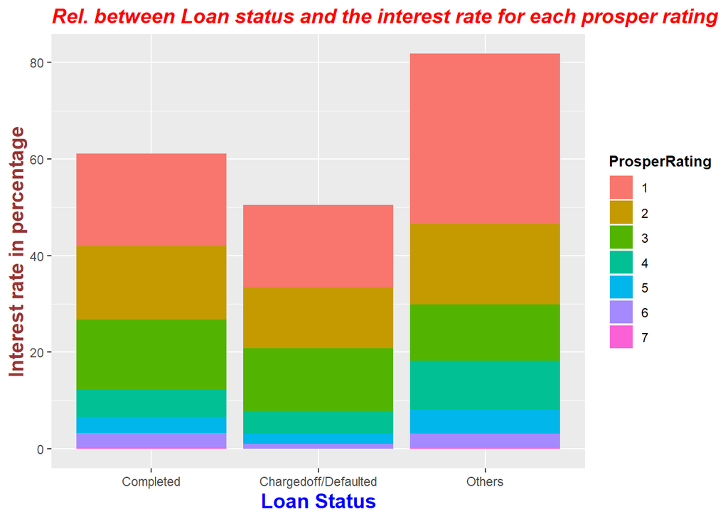

### Description One

that plot was answering the question : For those who registered their job on the listing as ‘not employed’ did they get higher interest and did they defaulted or completed their loans ?

### Plot Two

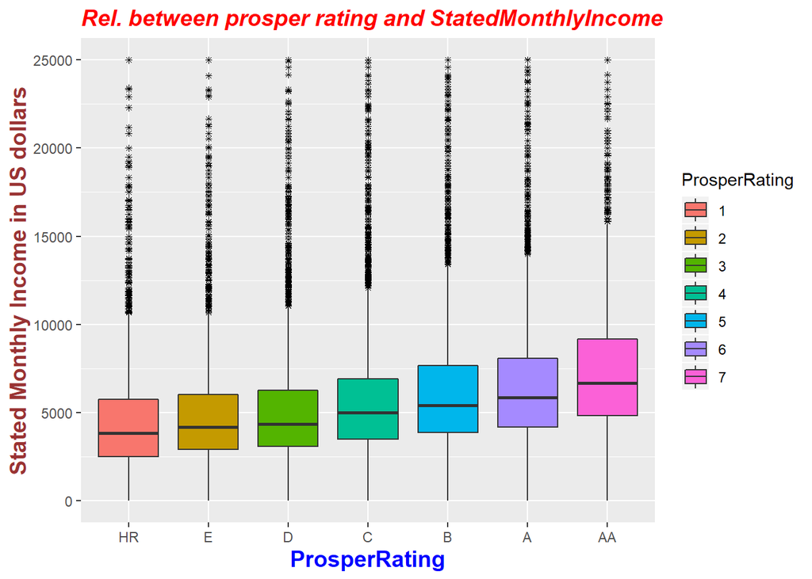

### Description Two

I wanted to see what makes a borrower take a good grade for his loan specifically how his income effect that , we can see that as the income increase the probability of getting a higher rating increase and that indeed is one of the factors affecting the outcome

### Plot Three

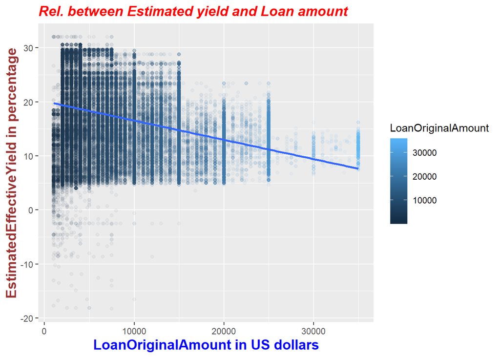

### Description Three

what is a better strategy for investing in loans ?Lending larger amounts of money or investing in several smaller loans? it appears that Several smaller Loans are more beneficial ! it shows that most of the yield that exceeds the 30% are below 15000 , where for the loans that have a median of 4000 and third quartile limit of 7500 dollars

# Reflection

First of all there were many variables that i have never encountered or worked with , specially the different terms describing loans , knowing these variables and how they naturally effect each other was important to ask the right questions yet it required time , the number of variables was high and i couldn’t just concentrate my findings on a few of them as that won’t be efficient i intended to group the listings by the Borrowers and explore patterns over time but there wasn’t enough number of listings for each member as most of the listings had unique Borrowers , knowing how the behaviours and the types of loans a regular Prosper Borrowr do would have been intuitive Also how the loans differ by different state is a good topic to take aboutt and maybe some laws in some of the states or the finicial state can explain some of the loan patterns